# NHL Contract Year Effects: Player Performance and Expectations (2014/2015-2024/2025)

### 4.1 Player Name Correction

After identifying more than 1,000 player names appearing in contract_years but not in skater_season_stats, we investigated the source of these mismatches. Manual inspection of several examples revealed two main categories:

**1. Players who never appeared in the NHL during our timespan despite signing an NHL contract**

- Example: *Luke Walker* signed with Colorado but never played an NHL game
- These cases are not relevant to our statistical analysis and can be safely ignored

**2. Players whose names differ slightly between datasets**

- Example: *Pat Dwyer* / *Patrick Dwyer*
- These require correction so their season data can be properly joined to their contract records

To detect and correct these discrepancies, we will perform the following steps:

- **Export** the unmatched player list from BigQuery
- **Export** the list of all unique player names from skater_season_stats
- **Run fuzzy matching in Python** with RapidFuzz, retrieving the top three closest *skater_season_stats* matches for each unmatched *contract_year* name
- **Import the results into Google Sheets**, sort by the match score, and manually select the correct match (or mark as unmatched) in the *correct_match* column
- **Apply corrections** in the original Google Sheets files prior to re-uploading the cleaned datasets to BigQuery

```python
from rapidfuzz import process, fuzz
import pandas as pd

df_contract = pd.read_csv("Data/contractYear_unmatchedPlayerNames.csv")
df_nhl = pd.read_csv("Data/nhl_stats_uniquePlayerNames.csv")

nhl_names = df_nhl["playerName"].tolist()

results = []

# Find the top 3 matches for each unmatched name

for name in df_contract["playerName"]:
    matches = process.extract(
        name,
        nhl_names,
        scorer=fuzz.token_sort_ratio,
        limit=3
    )

    # Fill with blanks if fewer than 3 matches
    while len(matches) < 3:
        matches.append(("", 0.0, 0))

    row = {
        "contract_name": name,
        "nhl_name_1": matches[0][0],
        "match_score_1": matches[0][1],
        "nhl_name_2": matches[1][0],
        "match_score_2": matches[1][1],
        "nhl_name_3": matches[2][0],
        "match_score_3": matches[2][1],
        "correct_match": ""           # fill in later manually
    }

    results.append(row)

df_results = pd.DataFrame(results)
df_results.to_csv("Data/name_fuzzy_matches_top3.csv", index=False)

df_results.head()
```

|  | contract_name | nhl_name_1 | match_score_1 | nhl_name_2 | match_score_2 | nhl_name_3 | match_score_3 | correct_match |
| --- | --- | --- | --- | --- | --- | --- | --- | --- |
| 0 | A.J. Jenks | Jan Jenik | 63.157895 | A.J. Greer | 60.000000 | B.J. Crombeen | 52.173913 |  |
| 1 | Aarne Talvitie | Aaron Volpatti | 57.142857 | Travis Sanheim | 57.142857 | Tyler Angle | 56.000000 |  |
| 2 | Aaron Luchuk | Anton Babchuk | 64.000000 | Aaron Palushaj | 61.538462 | Lucas Carlsson | 61.538462 |  |
| 3 | Adam Almqvist | Adam Almquist | 92.307692 | Adam Boqvist | 80.000000 | Adam Burish | 58.333333 |  |
| 4 | Adam Chapie | Craig Adams | 72.727273 | Adam Cracknell | 64.000000 | Adam Klapka | 63.636364 |  |

After reviewing the fuzzy-match output, we manually corrected **169 player names**, while **843 players remained unmatched**.  
A random audit of the remaining unmatched names showed that these players either:

- Never played an NHL game, or
- Only played in the NHL outside of the 2012/2013 - 2024/2025 seasons covered by our dataset

Given this, we can safely exclude the remaining unmatched players from contract year analysis.  
Corrections will be applied directly in the Google Sheets datasets and reuploaded to BigQuery.

### 4.2 Removing Early Signers

With the updated *contract_years* and *early_signers* tables imported back into SQL, we can proceed.  
We'll remove the *early_signers* from the *contract_years* by matching *playerName* and *season* and creating a new table, *contract_years_no_early*.

```
CREATE OR REPLACE TABLE `nhl_contract_project.contract_years_no_early` AS
SELECT *
FROM `nhl_contract_project.contract_years` c
WHERE NOT EXISTS (
  SELECT 1
  FROM `nhl_contract_project.early_signers` e
  WHERE c.playerName = e.playerName
    AND c.season = e.season
)
ORDER BY season ASC, playerName ASC;

SELECT
  (SELECT COUNT(*) FROM `nhl_contract_project.contract_years`) -
  (SELECT COUNT(*) FROM `nhl_contract_project.contract_years_no_early`)
AS records_removed;
```

486 *early_signer* rows were removed from *contract_years* in the new table.

### 4.3 Adding the Contract Year Column

Now that we've created the *contract_years_no_early* table as our finalized dataset of player contract years, we'll add a new boolean column to the *skater_season_stats* table, and use that new table to fill it out.  
We'll also add a *free_agent_type* column and fill it with the partial *fa_type* data, since we may be able to add to this and use it at some point.  
The result will be saved as a new table *skater_season_stats_with_contract*.

```
CREATE OR REPLACE TABLE `nhl_contract_project.skater_season_stats_with_contract` AS
SELECT
    s.*,
    CASE
        WHEN c.playerName IS NOT NULL THEN TRUE
        ELSE FALSE
    END AS contract_year,
    c.fa_type AS free_agent_type
FROM `nhl_contract_project.skater_season_stats` s
LEFT JOIN `nhl_contract_project.contract_years_no_early` c
    ON s.playerName = c.playerName
    AND s.season = c.season;
```

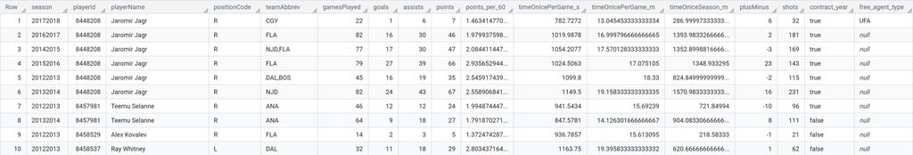

## 5. Exporting to Python

Now that we have our fully merged dataset (*skater_season_stats_with_contract*), we will:

1. Export a CSV backup from BigQuery
2. Load the same table directly into Python for further analysis and modeling

```
SELECT *
FROM `nhl_contract_project.skater_season_stats_with_contract`
ORDER BY playerName, season;
```